# Part I - (Bike Sales Dataset Exploration)

## Introduction

> This project is on the exploration of dataset containing bike sales.

## Preliminary Wrangling

```python
# import all packages and set plots to be embedded inline
import numpy as np
import pandas as pd
import matplotlib.pyplot as plt
import seaborn as sb
import seaborn as sns
%matplotlib inline
```

Load Dataset and carryout some dat wrangling

```python
#Name of dataframe is Sales
df_sales = pd.read_csv('Sales.csv')
```

```python
#view 10 rows in our dataset
df_sales.head()
```

|  | Date | Day | Month | Year | Customer_Age | Age_Group | Customer_Gender | Country | State | Product_Category | Sub_Category | Product | Order_Quantity | Unit_Cost | Unit_Price | Profit | Cost | Revenue |
| --- | --- | --- | --- | --- | --- | --- | --- | --- | --- | --- | --- | --- | --- | --- | --- | --- | --- | --- |
| 0 | 2013-11-26 | 26 | November | 2013 | 19 | Youth (<25) | M | Canada | British Columbia | Accessories | Bike Racks | Hitch Rack - 4-Bike | 8 | 45 | 120 | 590 | 360 | 950 |
| 1 | 2015-11-26 | 26 | November | 2015 | 19 | Youth (<25) | M | Canada | British Columbia | Accessories | Bike Racks | Hitch Rack - 4-Bike | 8 | 45 | 120 | 590 | 360 | 950 |
| 2 | 2014-03-23 | 23 | March | 2014 | 49 | Adults (35-64) | M | Australia | New South Wales | Accessories | Bike Racks | Hitch Rack - 4-Bike | 23 | 45 | 120 | 1366 | 1035 | 2401 |
| 3 | 2016-03-23 | 23 | March | 2016 | 49 | Adults (35-64) | M | Australia | New South Wales | Accessories | Bike Racks | Hitch Rack - 4-Bike | 20 | 45 | 120 | 1188 | 900 | 2088 |
| 4 | 2014-05-15 | 15 | May | 2014 | 47 | Adults (35-64) | F | Australia | New South Wales | Accessories | Bike Racks | Hitch Rack - 4-Bike | 4 | 45 | 120 | 238 | 180 | 418 |

```python
# high-level overview of data shape and composition
print(df_sales.shape)     # Checks for dataframe size
print(df_sales.dtypes)   # checks for datatypes
```

```
(113036, 18)
Date                object
Day                  int64
Month               object
Year                 int64
Customer_Age         int64
Age_Group           object
Customer_Gender     object
Country             object
State               object
Product_Category    object
Sub_Category        object
Product             object
Order_Quantity       int64
Unit_Cost            int64
Unit_Price           int64
Profit               int64
Cost                 int64
Revenue              int64
dtype: object
```

```python
# descriptive statistics for numeric variables
print(df_sales.describe())
```

```
                 Day           Year   Customer_Age  Order_Quantity  \
count  113036.000000  113036.000000  113036.000000   113036.000000
mean       15.665753    2014.401739      35.919212       11.901660
std         8.781567       1.272510      11.021936        9.561857
min         1.000000    2011.000000      17.000000        1.000000
25%         8.000000    2013.000000      28.000000        2.000000
50%        16.000000    2014.000000      35.000000       10.000000
75%        23.000000    2016.000000      43.000000       20.000000
max        31.000000    2016.000000      87.000000       32.000000

           Unit_Cost     Unit_Price         Profit           Cost  \
count  113036.000000  113036.000000  113036.000000  113036.000000
mean      267.296366     452.938427     285.051665     469.318695
std       549.835483     922.071219     453.887443     884.866118
min         1.000000       2.000000     -30.000000       1.000000
25%         2.000000       5.000000      29.000000      28.000000
50%         9.000000      24.000000     101.000000     108.000000
75%        42.000000      70.000000     358.000000     432.000000
max      2171.000000    3578.000000   15096.000000   42978.000000

             Revenue
count  113036.000000
mean      754.370360
std      1309.094674
min         2.000000
25%        63.000000
50%       223.000000
75%       800.000000
max     58074.000000
```

```python
# Explore data type of the datasets
df_sales.info()
```

```
<class 'pandas.core.frame.DataFrame'>
RangeIndex: 113036 entries, 0 to 113035
Data columns (total 18 columns):
Date                113036 non-null object
Day                 113036 non-null int64
Month               113036 non-null object
Year                113036 non-null int64
Customer_Age        113036 non-null int64
Age_Group           113036 non-null object
Customer_Gender     113036 non-null object
Country             113036 non-null object
State               113036 non-null object
Product_Category    113036 non-null object
Sub_Category        113036 non-null object
Product             113036 non-null object
Order_Quantity      113036 non-null int64
Unit_Cost           113036 non-null int64
Unit_Price          113036 non-null int64
Profit              113036 non-null int64
Cost                113036 non-null int64
Revenue             113036 non-null int64
dtypes: int64(9), object(9)
memory usage: 15.5+ MB
```

```python
#Check for duplicate
df_sales.duplicated().sum()
```

```
1000
```

```python
df_sales.drop_duplicates(inplace=True)
```

```python
df_sales.head()
```

|  | Date | Day | Month | Year | Customer_Age | Age_Group | Customer_Gender | Country | State | Product_Category | Sub_Category | Product | Order_Quantity | Unit_Cost | Unit_Price | Profit | Cost | Revenue |
| --- | --- | --- | --- | --- | --- | --- | --- | --- | --- | --- | --- | --- | --- | --- | --- | --- | --- | --- |
| 0 | 2013-11-26 | 26 | November | 2013 | 19 | Youth (<25) | M | Canada | British Columbia | Accessories | Bike Racks | Hitch Rack - 4-Bike | 8 | 45 | 120 | 590 | 360 | 950 |
| 1 | 2015-11-26 | 26 | November | 2015 | 19 | Youth (<25) | M | Canada | British Columbia | Accessories | Bike Racks | Hitch Rack - 4-Bike | 8 | 45 | 120 | 590 | 360 | 950 |
| 2 | 2014-03-23 | 23 | March | 2014 | 49 | Adults (35-64) | M | Australia | New South Wales | Accessories | Bike Racks | Hitch Rack - 4-Bike | 23 | 45 | 120 | 1366 | 1035 | 2401 |
| 3 | 2016-03-23 | 23 | March | 2016 | 49 | Adults (35-64) | M | Australia | New South Wales | Accessories | Bike Racks | Hitch Rack - 4-Bike | 20 | 45 | 120 | 1188 | 900 | 2088 |
| 4 | 2014-05-15 | 15 | May | 2014 | 47 | Adults (35-64) | F | Australia | New South Wales | Accessories | Bike Racks | Hitch Rack - 4-Bike | 4 | 45 | 120 | 238 | 180 | 418 |

```python
df_sales.duplicated().sum()
```

```
0
```

```python
#Check for Missing values
df_sales.isnull().sum()
```

```
Date                0
Day                 0
Month               0
Year                0
Customer_Age        0
Age_Group           0
Customer_Gender     0
Country             0
State               0
Product_Category    0
Sub_Category        0
Product             0
Order_Quantity      0
Unit_Cost           0
Unit_Price          0
Profit              0
Cost                0
Revenue             0
dtype: int64
```

```python
df_sales.describe()
```

[output not shown]

```python
df_sales.shape
```

```
(112036, 18)
```

### What is/are the main feature(s) of interest in your dataset?

> I am interested in looking at factors/variables that influences sales. I am also keen to know the age group that buys different products and which country and states produces the highest revenue and profit.

### What features in the dataset do you think will help support your investigation into your feature(s) of interest?

> I think age of customer will countribute significantly to the sales of bike and profit the store makes. The younger people might tend to purchase more than the old people. Also, the cost might also influence the sales.

## Univariate Exploration

##### Quantitative Varibales

First Lets look at Revenue with histogram plot

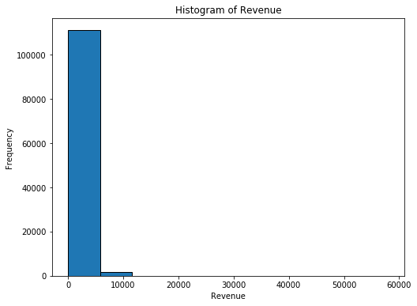

```python
# Create a figure with the  size
plt.figure(figsize=(8, 6))

# Plot the histogram of the 'Revenue' variable
# Set the number of bins to 10 and the edge color of the bars to black
plt.hist(df_sales['Revenue'], bins=10, edgecolor='black')

# Set the label for the x-axis
plt.xlabel('Revenue')

# Set the label for the y-axis
plt.ylabel('Frequency')

# Set the title of the histogram
plt.title('Histogram of Revenue')

# Display the histogram
plt.show()
```

Lets filter the revenue with less than 12000

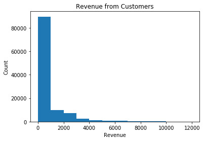

```python
# Filter the df_sales to include only rows where 'Revenue' is less than or equal to 12000
df_sales_sub = df_sales[df_sales['Revenue'] <= 12000]

# Define the bin edges for the histogram based on the maximum revenue in the filtered DataFrame
bin_edges = np.arange(0, df_sales_sub['Revenue'].max() + 1000, 1000)

# Plot the histogram of 'Revenue' using the filtered DataFrame and specified bin edges
plt.hist(data=df_sales_sub, x='Revenue', bins=bin_edges)

# Set the label for the x-axis
plt.xlabel('Revenue')

# Set the label for the y-axis
plt.ylabel('Count')

# Set the title of the histogram
plt.title('Revenue from Customers')

# Display the histogram
plt.show()
```

Lets modify the scale

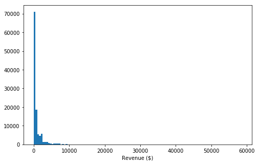

```python
# start with a standard-scaled plot
binsize = 500
bins = np.arange(0, df_sales['Revenue'].max()+binsize, binsize)

plt.figure(figsize=[8, 5])
plt.hist(data = df_sales, x = 'Revenue', bins = bins)
plt.xlabel('Revenue ($)')
plt.show()
```

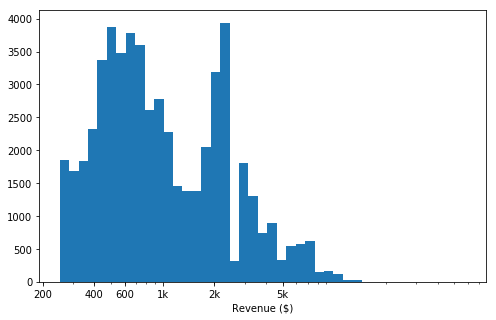

```python
# We can as well transform using the Log scale since it has a long tail distribution
log_binsize = 0.055
bins = 10 ** np.arange(2.4, np.log10(df_sales['Revenue'].max())+log_binsize, log_binsize)

plt.figure(figsize=[8, 5])
plt.hist(data = df_sales, x = 'Revenue', bins = bins)
plt.xscale('log')
plt.xticks([ 200, 400, 600, 1e3, 2e3, 5e3,], [200, 400,600, '1k', '2k', '5k'])
plt.xlabel('Revenue ($)')
plt.show()
```

Lets look at Profit with histogram plot

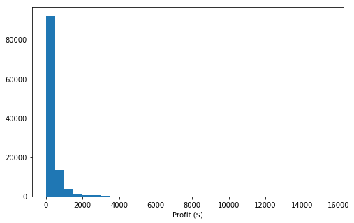

```python
# start with a standard-scaled plot
binsize = 500
bins = np.arange(0, df_sales['Profit'].max()+binsize, binsize)

plt.figure(figsize=[8, 5])
plt.hist(data = df_sales, x = 'Profit', bins = bins)
plt.xlabel('Profit ($)')
plt.show()
```

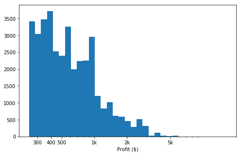

```python
# there's a long tail in the distribution, so let's put it on a log scale instead
log_binsize = 0.055
bins = 10 ** np.arange(2.4, np.log10(df_sales['Profit'].max())+log_binsize, log_binsize)

plt.figure(figsize=[8, 5])
plt.hist(data = df_sales, x = 'Profit', bins = bins)
plt.xscale('log')
plt.xticks([ 300, 400, 500, 1e3, 2e3, 5e3,], [300, 400,500, '1k', '2k', '5k'])
plt.xlabel('Profit ($)')
plt.show()
```

Profit has a long taied distribution here, with most profit between 250 and 1000. Also with few around 1000-2000. Howerver, when I plotted on log-scale, the profit distribution looks unimodal. From the distribution 400 happens to have the highest mode.

Customer_Age

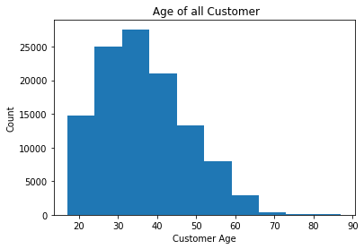

```python
plt.hist(data = df_sales, x = 'Customer_Age');
plt.xlabel('Customer Age');
plt.ylabel('Count');
plt.title(" Age of all Customer");
```

From the distribution above it very obvious that Customer age is skewed to the Right

```python
df_sales["Customer_Age"].mean()
```

```
35.919211578612121
```

```python
df_sales["Customer_Age"].median()
```

```
35.0
```

```python
df_sales["Customer_Age"].mode()
```

```
0    31
dtype: int64
```

Order_Quantity

```python
Order_counts = df_sales["Order_Quantity"].value_counts()
print(Order_counts)
```

```
1     22626
2      7650
3      5142
4      3436
6      3076
5      3039
18     3010
7      2993
24     2983
16     2978
9      2948
10     2941
14     2914
15     2906
12     2899
```

[output cut: 18 more lines]

Customer has actually ordered one Quantity of product **22626** times